# Motorcycle accident findings

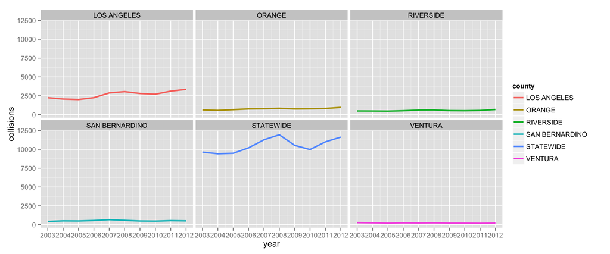

**Number of motorcyclists injured in collisions (SWITRS)**

| year | statewide | los angeles | orange | riverside | san bernardino | ventura |
| --- | --- | --- | --- | --- | --- | --- |
| 2012 | 11472 | 3210 | 954 | 682 | 494 | 217 |
| 2011 | 10906 | 3068 | 798 | 547 | 508 | 184 |
| 2010 | 9969 | 2657 | 756 | 507 | 467 | 208 |
| 2009 | 10479 | 2709 | 759 | 520 | 478 | 200 |
| 2008 | 11764 | 2935 | 794 | 621 | 567 | 248 |
| 2007 | 11172 | 2803 | 754 | 600 | 653 | 221 |
| 2006 | 10188 | 2188 | 751 | 514 | 545 | 238 |
| 2005 | 9347 | 1921 | 629 | 467 | 498 | 204 |
| 2004 | 9488 | 2028 | 536 | 481 | 501 | 243 |
| 2003 | 9681 | 2168 | 605 | 491 | 429 | 277 |

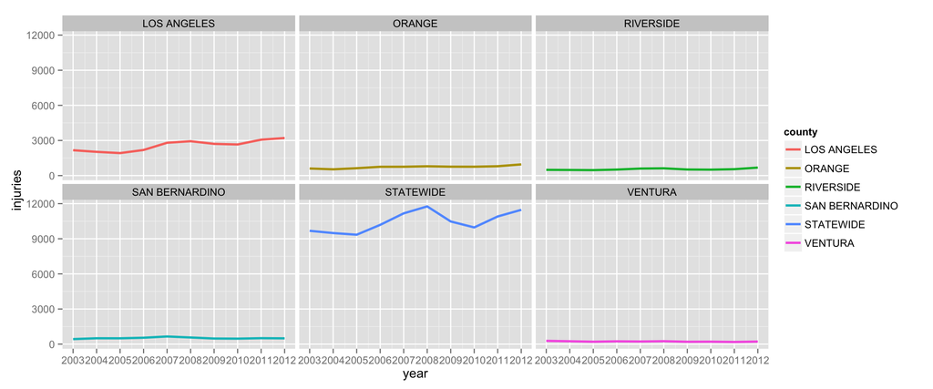

**Statewide percent of all collisions that are fatal (SWITRS)**

| year | no_total | no_fatal | statewide |
| --- | --- | --- | --- |
| 2012 | 162454 | 2758 | 1.698 |
| 2011 | 161743 | 2628 | 1.625 |
| 2010 | 163614 | 2520 | 1.54 |
| 2009 | 166329 | 2805 | 1.686 |
| 2008 | 173609 | 3113 | 1.793 |
| 2007 | 188551 | 3557 | 1.887 |
| 2006 | 193750 | 3793 | 1.958 |
| 2005 | 202530 | 3822 | 1.887 |
| 2004 | 207087 | 3701 | 1.787 |
| 2003 | 207900 | 3726 | 1.792 |

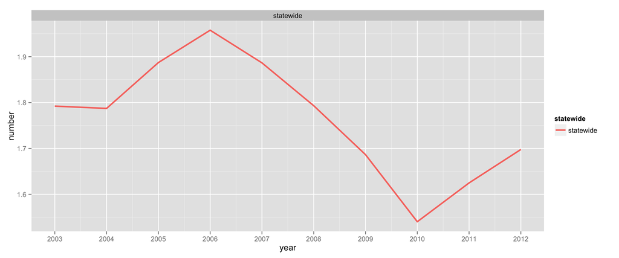

**Statewide percent of collisions involving motorcycles that are fatal (SWITRS)**

| year | no_total | no_fatal | statewide |
| --- | --- | --- | --- |
| 2012 | 11617 | 444 | 3.822 |
| 2011 | 10990 | 407 | 3.703 |
| 2010 | 9972 | 341 | 3.42 |
| 2009 | 10523 | 380 | 3.611 |
| 2008 | 11927 | 518 | 4.343 |
| 2007 | 11262 | 455 | 4.04 |
| 2006 | 10194 | 421 | 4.13 |
| 2005 | 9472 | 398 | 4.202 |
| 2004 | 9408 | 342 | 3.635 |
| 2003 | 9623 | 358 | 3.72 |

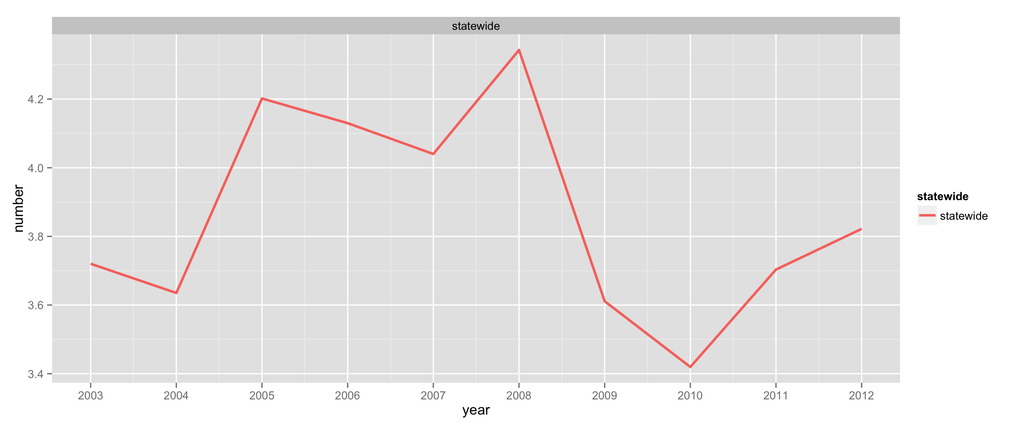

**Statewide motorcycle registrations (DMV)**

| year | statewide | los angeles | orange | riverside | san bernardino | ventura |
| --- | --- | --- | --- | --- | --- | --- |
| 2012 | 832304 | 154108 | 61161 | 45490 | 42829 | 24167 |
| 2011 | 818650 | 150143 | 59563 | 43893 | 42153 | 23997 |
| 2010 | 808913 | 146703 | 58313 | 42851 | 42228 | 23999 |
| 2009 | 809129 | 146822 | 58482 | 42528 | 43037 | 23992 |
| 2008 | 824244 | 149987 | 59187 | 43888 | 44945 | 24442 |
| 2007 | 772524 | 139842 | 55708 | 41820 | 42879 | 23433 |
| 2006 | 732547 | 131515 | 52928 | 39825 | 40582 | 22433 |
| 2005 | 680857 | 121675 | 49028 | 36080 | 37084 | 21279 |
| 2004 | 641905 | 114622 | 47051 | 32401 | 33280 | 20150 |
| 2003 | 569226 | 100693 | 42355 | 27111 | 28146 | 18013 |
| 2002 | 536060 | 95233 | 40484 | 23091 | 24889 | 16548 |
| 2001 | 495271 | 87986 | 37404 | 21335 | 22996 | 15289 |

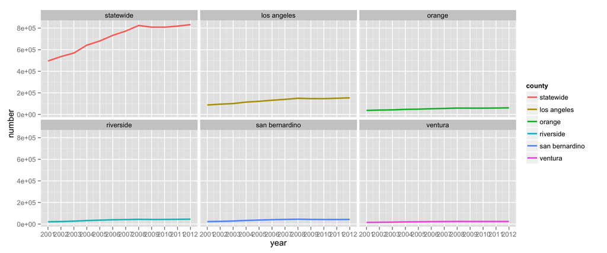

**Fatalities per 100,000 registered motorcycles (SWITRS, DMV)**

- Includes out of state but not fee exempt registrations

| year | statewide | los angeles | orange | riverside | san bernardino | ventura |
| --- | --- | --- | --- | --- | --- | --- |
| 2012 | 54.19 | 73.33 | 37.61 | 50.56 | 65.38 | 49.65 |
| 2011 | 50.94 | 57.94 | 33.58 | 38.73 | 85.4 | 54.17 |
| 2010 | 43.02 | 48.4 | 34.3 | 84.01 | 61.57 | 29.17 |
| 2009 | 47.33 | 54.49 | 29.07 | 70.54 | 74.35 | 54.18 |
| 2008 | 64.18 | 74.01 | 55.76 | 75.19 | 75.65 | 45 |
| 2007 | 60.19 | 58.64 | 39.49 | 98.04 | 62.97 | 21.34 |
| 2006 | 59.11 | 58.55 | 49.12 | 77.84 | 101 | 53.49 |
| 2005 | 59.34 | 56.71 | 59.15 | 69.29 | 86.29 | 51.69 |
| 2004 | 54.53 | 60.2 | 55.26 | 49.38 | 78.12 | 44.66 |
| 2003 | 64.65 | 79.45 | 49.58 | 88.52 | 88.82 | 72.17 |

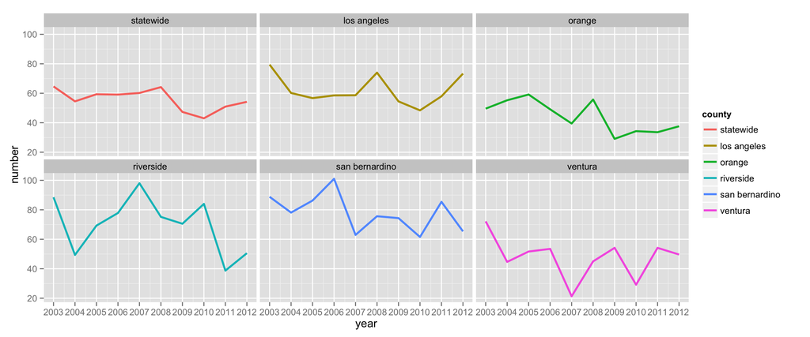

**Statewide non-motorcycle registrations (DMV)**

- Includes out of state but not fee exempt registrations

| year | statewide | los angeles | orange | riverside | san bernardino | ventura |
| --- | --- | --- | --- | --- | --- | --- |
| 2012 | 30420434 | 7268146 | 2478503 | 1679297 | 1586408 | 726898 |
| 2011 | 30304169 | 7210430 | 2460392 | 1667599 | 1586424 | 726296 |
| 2010 | 30522487 | 7263922 | 2462161 | 1665099 | 1597380 | 729948 |
| 2009 | 30416002 | 7254728 | 2450780 | 1647065 | 1589399 | 727082 |
| 2008 | 30519452 | 7348735 | 2467240 | 1641358 | 1595849 | 728670 |
| 2007 | 30710868 | 7446940 | 2485896 | 1658176 | 1624483 | 732077 |
| 2006 | 30769253 | 7457728 | 2492921 | 1664685 | 1644832 | 737934 |
| 2005 | 30385291 | 7393241 | 2455174 | 1588542 | 1600837 | 726140 |
| 2004 | 30363406 | 7399621 | 2476801 | 1525916 | 1558296 | 733236 |
| 2003 | 28380760 | 6904329 | 2316270 | 1365275 | 1414780 | 687148 |
| 2002 | 28466339 | 6914612 | 2326711 | 1321141 | 1382324 | 687323 |
| 2001 | 27300291 | 6611740 | 2271123 | 1239607 | 1307847 | 666810 |

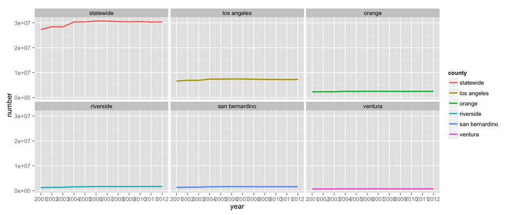

**Statewide injuries in motorcycle accidents by age (Chris Cochran)**

| age | X1997 | X1998 | X1999 | X2000 | X2001 | X2002 | X2003 | X2004 | X2005 | X2006 | X2007 | X2008 | X2009 | X2010 | X2011 | X2012 |
| --- | --- | --- | --- | --- | --- | --- | --- | --- | --- | --- | --- | --- | --- | --- | --- | --- |
| 0-4 | 5 | 0 | 4 | 0 | 5 | 17 | 10 | 15 | 15 | 9 | 8 | 19 | 15 | 15 | 9 | 19 |
| 5-14 | 126 | 120 | 103 | 141 | 144 | 191 | 257 | 276 | 171 | 149 | 166 | 151 | 120 | 103 | 106 | 89 |
| 15-24 | 1601 | 1305 | 1330 | 1567 | 1768 | 1764 | 2126 | 2151 | 2175 | 2381 | 2739 | 2700 | 2307 | 1966 | 2252 | 2592 |
| 25-34 | 2359 | 1978 | 2021 | 2223 | 2377 | 2342 | 2370 | 2227 | 2241 | 2364 | 2654 | 2737 | 2459 | 2497 | 2851 | 3151 |
| 35-44 | 1800 | 1535 | 1701 | 1851 | 1941 | 2072 | 2135 | 2030 | 1904 | 2170 | 2168 | 2273 | 2002 | 1862 | 1912 | 1890 |
| 45-54 | 1071 | 927 | 1182 | 1314 | 1489 | 1608 | 1788 | 1768 | 1776 | 1916 | 2129 | 2329 | 2022 | 2025 | 1984 | 1958 |
| 55-64 | 305 | 330 | 432 | 400 | 520 | 607 | 728 | 783 | 815 | 923 | 978 | 1168 | 1194 | 1135 | 1309 | 1273 |
| 65-74 | 94 | 87 | 96 | 116 | 100 | 130 | 170 | 152 | 155 | 181 | 223 | 285 | 233 | 278 | 356 | 390 |
| 75-84 | 21 | 12 | 24 | 16 | 22 | 38 | 31 | 23 | 33 | 29 | 37 | 47 | 31 | 47 | 60 | 51 |
| 85 and over | 3 | 2 | 4 | 7 | 1 | 7 | 1 | 1 | 7 | 4 | 6 | 6 | 8 | 3 | 11 | 9 |
| Not stated | 31 | 34 | 36 | 28 | 38 | 61 | 65 | 62 | 55 | 62 | 64 | 49 | 56 | 38 | 56 | 50 |

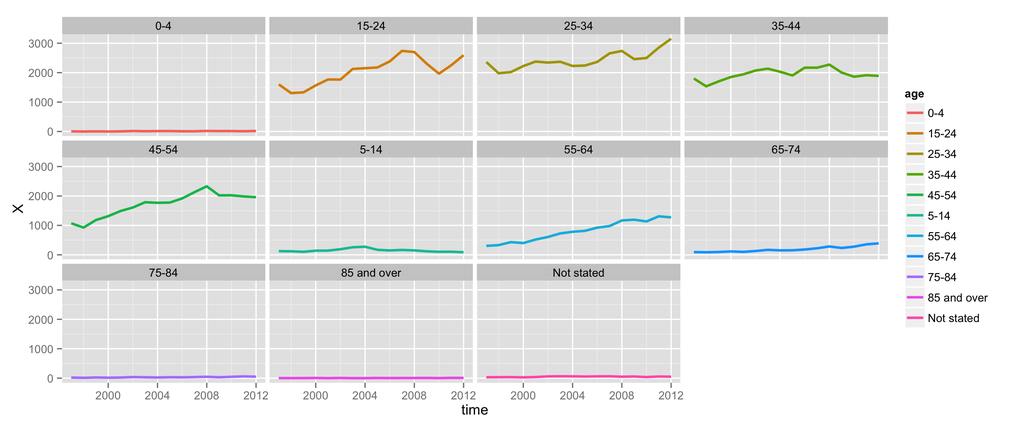

**Statewide fatalities in motorcycle accidents by age (Chris Cochran)**

| age | X1997 | X1998 | X1999 | X2000 | X2001 | X2002 | X2003 | X2004 | X2005 | X2006 | X2007 | X2008 | X2009 | X2010 | X2011 | X2012 |
| --- | --- | --- | --- | --- | --- | --- | --- | --- | --- | --- | --- | --- | --- | --- | --- | --- |
| 0-4 | 0 | 0 | 0 | 0 | 0 | 0 | 0 | 0 | 0 | 0 | 2 | 0 | 0 | 0 | 0 | 0 |
| 5-14 | 2 | 1 | 2 | 2 | 1 | 2 | 4 | 5 | 5 | 1 | 3 | 2 | 1 | 1 | 1 | 1 |
| 15-24 | 47 | 33 | 41 | 44 | 61 | 60 | 64 | 77 | 81 | 82 | 102 | 122 | 74 | 58 | 71 | 68 |
| 25-34 | 68 | 60 | 57 | 71 | 76 | 74 | 73 | 81 | 89 | 86 | 96 | 125 | 88 | 67 | 96 | 116 |
| 35-44 | 53 | 62 | 63 | 72 | 72 | 78 | 96 | 76 | 80 | 108 | 96 | 86 | 65 | 80 | 77 | 72 |
| 45-54 | 35 | 25 | 42 | 55 | 48 | 65 | 84 | 68 | 86 | 94 | 110 | 100 | 84 | 80 | 84 | 92 |
| 55-64 | 19 | 14 | 20 | 18 | 26 | 32 | 31 | 33 | 49 | 51 | 42 | 62 | 52 | 48 | 60 | 73 |
| 65-74 | 4 | 2 | 5 | 11 | 6 | 5 | 14 | 7 | 10 | 9 | 10 | 20 | 13 | 11 | 24 | 23 |
| 75-84 | 4 | 2 | 0 | 1 | 3 | 1 | 1 | 1 | 4 | 1 | 3 | 7 | 4 | 2 | 4 | 5 |
| 85 and over | 1 | 0 | 0 | 0 | 2 | 1 | 0 | 0 | 0 | 0 | 0 | 1 | 0 | 1 | 0 | 0 |
| Not stated | 2 | 1 | 0 | 1 | 0 | 0 | 1 | 2 | 0 | 1 | 1 | 4 | 2 | 0 | 0 | 1 |

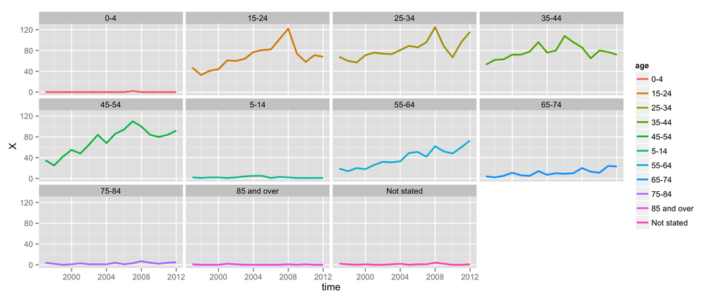

**Statewide motorcyclists killed by type of collision (SWITRS)**

| year | – | Head On | Sideswipe | Rear End | Broadside | Hit Object | Overturned | Veh/Ped | Other |
| --- | --- | --- | --- | --- | --- | --- | --- | --- | --- |
| 2012 | 0 | 32 | 23 | 50 | 133 | 127 | 75 | 2 | 9 |
| 2011 | 1 | 41 | 30 | 52 | 102 | 114 | 72 | 1 | 4 |
| 2010 | 0 | 38 | 20 | 37 | 99 | 104 | 39 | 1 | 10 |
| 2009 | 0 | 42 | 24 | 37 | 100 | 109 | 70 | 0 | 1 |
| 2008 | 3 | 53 | 41 | 66 | 122 | 158 | 80 | 0 | 6 |
| 2007 | 0 | 52 | 26 | 44 | 106 | 122 | 107 | 0 | 8 |
| 2006 | 0 | 69 | 21 | 40 | 101 | 121 | 76 | 0 | 5 |
| 2005 | 1 | 50 | 22 | 33 | 109 | 107 | 76 | 0 | 6 |
| 2004 | 2 | 48 | 30 | 35 | 74 | 92 | 65 | 0 | 4 |
| 2003 | 2 | 48 | 22 | 29 | 97 | 109 | 50 | 0 | 11 |

**Los Angeles County motorcyclists killed by type of collision**

| year | – | Head-On | Sideswipe | Rear End | Broadside | Hit Object | Overturned | Veh/Ped | Other |
| --- | --- | --- | --- | --- | --- | --- | --- | --- | --- |
| 2012 | 0 | 6 | 6 | 12 | 53 | 24 | 11 | 0 | 1 |
| 2011 | 0 | 9 | 9 | 14 | 30 | 13 | 11 | 0 | 1 |
| 2010 | 0 | 2 | 5 | 13 | 26 | 19 | 4 | 0 | 2 |
| 2009 | 0 | 3 | 7 | 4 | 33 | 25 | 8 | 0 | 0 |
| 2008 | 2 | 8 | 12 | 12 | 33 | 30 | 13 | 0 | 1 |
| 2007 | 0 | 9 | 7 | 10 | 24 | 18 | 13 | 0 | 1 |
| 2006 | 0 | 10 | 6 | 8 | 26 | 18 | 9 | 0 | 0 |
| 2005 | 0 | 7 | 3 | 8 | 30 | 16 | 5 | 0 | 0 |
| 2004 | 1 | 4 | 9 | 6 | 19 | 14 | 15 | 0 | 1 |
| 2003 | 0 | 6 | 8 | 5 | 31 | 20 | 9 | 0 | 1 |

**Los Angeles County collisions involving motorcycles (SWITRS)**

| Year | Not Stated | Clear | Cloudy | Raining | Snowing | Fog | Other | Wind |
| --- | --- | --- | --- | --- | --- | --- | --- | --- |
| 2012 | 7 | 3048 | 262 | 26 |  | 4 |  | 2 |
| 2011 | 14 | 2850 | 226 | 20 |  | 1 |  | 1 |
| 2010 | 3 | 2422 | 241 | 39 |  | 5 | 1 |  |
| 2009 | 7 | 2579 | 189 | 17 |  | 6 | 2 | 2 |
| 2008 | 13 | 2809 | 201 | 16 |  | 4 | 1 | 4 |
| 2007 | 13 | 2653 | 195 | 14 |  | 2 |  |  |
| 2006 | 8 | 2047 | 179 | 12 |  |  |  |  |
| 2005 | 9 | 1819 | 156 | 13 | 1 | 2 | 1 | 1 |
| 2004 | 28 | 1867 | 153 | 13 | 1 | 3 |  | 1 |
| 2003 | 14 | 2008 | 211 | 8 | 1 | 1 |  | 2 |

```
## [1] TRUE
```